# ConsensusClustering-allNorm

**CONSENSUS CLUSTERING**

Following [1], the aim of this original approach is to find different groups of patients with similar type of cares. Thus is, instead of group them by variables, the clusters would be formed by groups of individual subjects.

**1. LOAD DATA AND SETTING THE ENVIRONMENT**

```r
#library(ALL)
## prueba http: // si https: // URLs no son compatibles
#source("https://bioconductor.org/biocLite.R")
#biocLite("ConsensusClusterPlus")
library(ConsensusClusterPlus)
#library(ALL)
```

```r
data = read.csv("/home/jpmanzano/Desktop/arreglado2.csv", sep = ",", header = T)
data = data[,-c(1,2)]

# Nominals
#data_cat$hospital_expire_flag = factor(data_cat$hospital_expire_flag, levels = c(0,1), labels=c("No","Si"))
data$vent = as.numeric(factor(data$vent, levels = c("No","Si"), labels=c(0,1)))
data$iot = as.numeric(factor(data$iot, levels = c("No","Si"), labels=c(0,1)))
data$transfusion = as.numeric(factor(data$transfusion, levels = c("No","Si"), labels=c(0,1)))
data$ecmo = as.numeric(factor(data$ecmo, levels = c("No","Si"), labels=c(0,1)))
data$coro = as.numeric(factor(data$coro, levels = c("No","Si"), labels=c(0,1)))
data$mechvent = as.numeric(factor(data$mechvent, levels = c("No","Si"), labels=c(0,1)))
data$oxygentherapy = as.numeric(factor(data$oxygentherapy, levels = c("No","Si"), labels=c(0,1)))
data$extubated = as.numeric(factor(data$extubated, levels = c("No","Si"), labels=c(0,1)))
data$selfextubated = as.numeric(factor(data$selfextubated, levels = c("No","Si"), labels=c(0,1)))
#data$first_hosp_stay = factor(data$first_hosp_stay, levels = c(0,1), labels=c("No","Si"))
data$sedation = as.numeric(factor(data$sedation, labels=c(0,1)))
#data$change_serv = factor(data$change_serv, labels=c("No","Si"))
#data$surg = factor(data$surg, labels=c("No","Si"))
data$vasopressor = as.numeric(factor(data$vasopressor, levels = c("No","Si"), labels=c(0,1)))
data$gender = as.numeric(factor(data$gender, levels = c("No","Si"), labels=c(0,1)))
data$rrt = as.numeric(factor(data$rrt, levels = c("No","Si"), labels=c(0,1)))

# Ordinales
#data$admission_type = as.numeric(factor(data$admission_type, levels = c("NEWBORN", "ELECTIVE", "EMERGENCY", "URGENCY"), labels = c(1,2,3,4), ordered = TRUE))
#data$icustay_seq = as.numeric(factor(data$icustay_seq, levels = c("1", "2", "3"), ordered = TRUE))


correlacionadas = c("meanbp_min", "weight_max", "height_first",
  "height_max", "creatinine_min", "glucose_min_y", "bicarbonate_min",
  "weight_first","hemoglobin_min", "aniongap_min", "admission_type", "icustay_seq")
data = data[ , -which(names(data) %in% correlacionadas)]

for(i in 1:dim(data)[2]){
    data[,i] = as.numeric(scale(data[,i]))
}

dim(data)
str(data)
```

1. 4360

2. 65

```
'data.frame':	4360 obs. of  65 variables:
 $ los_icu_cont   : num  -0.2281 -0.2796 -0.2829 -0.6524 -0.0199 ...
 $ aniongap_max   : num  0.267 0.522 -0.242 -0.496 -0.242 ...
 $ bicarbonate_max: num  0.825 -0.747 -1.376 -0.747 -0.433 ...
 $ creatinine_max : num  -0.349 0.192 -0.259 -0.529 0.372 ...
 $ chloride_min   : num  -2.201 0.0564 1.0825 0.4669 0.6721 ...
 $ chloride_max   : num  -1.333 -0.717 1.749 1.544 2.366 ...
 $ glucose_min_x  : num  0.409 0.787 1.782 -0.62 -0.483 ...
 $ hematocrit_min : num  1.4843 2.519 -0.8307 -1.9355 -0.0765 ...
 $ hematocrit_max : num  1.016 0.777 -1.143 -0.923 -2.162 ...
 $ platelet_min   : num  0.538 1.287 -0.699 -0.245 0.163 ...
 $ potassium_min  : num  1.382 0.698 -0.215 -1.128 -0.215 ...
 $ potassium_max  : num  -0.931 -0.825 -1.038 -0.825 -1.251 ...
 $ ptt_max        : num  -0.478 -0.804 -0.71 -0.163 0.455 ...
 $ inr_max        : num  -0.3238 -0.5238 -0.5238 0.0761 -0.6238 ...
```

[output cut: 51 more lines]

Note this dataset is the original one, without filtering outliers and with more patients in the set.

**CONSENSUS CLUSTERING**

Because clustering analyses can be non-robust to perturbations in the data, careful attention must be paid to achieving stable cluster membership. To address this, we applied a consensus clustering technique with the use of the R package ‘ConsensusClusterPlus’ [2,3,4]. In consensus clustering, the initial cohort is iteratively subsampled and cluster membership is determined at each iteration across a range of potential cluster numbers (k), starting from k=2 to a user-specified maximum (here k=8).

In each iteration, consensus clustering quantifies pairwise consensus values (i.e., the frequency with which two observations were members of the same cluster out of the total number of times they occurred together in all subsamples) for each value of k.

Main considerations:

- If the original variable was categorical (e.g. discharge location), we expanded it into a binary variable with the use of dummy variables. Thus, all variables used in the clustering analysis were represented by either continuous or binary variable.
- Data used in the analyses were standardized (i.e. set to a mean of zero with a standard deviation of 1).

```r
#install.packages("repr")
#install.packages("ConsensusClusterPlus")
library(ConsensusClusterPlus)
library(repr)  # To get control of the plot' sizes
options(repr.plot.width=4.5, repr.plot.height=4)
```

Search optimal k from 2 to 8, with a k-means & Euclidean distance metric approach:

```
end fraction
clustered
clustered
```

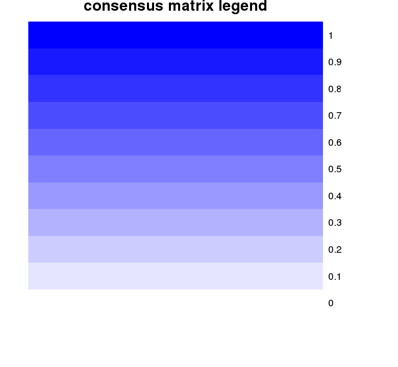

```
clustered
```

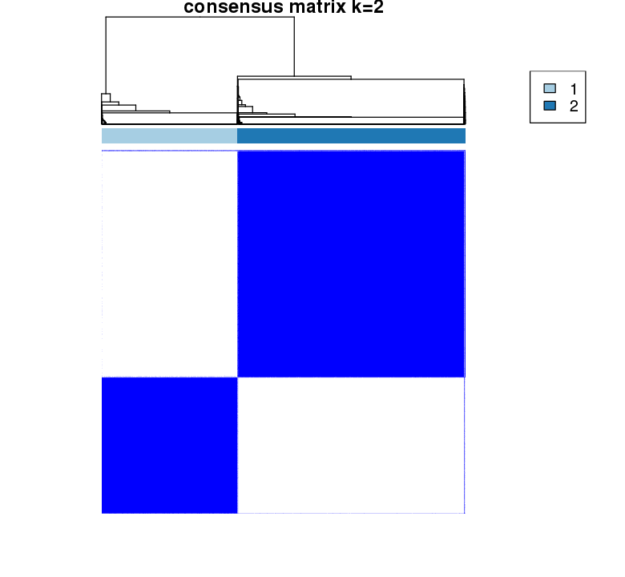

```
clustered
```

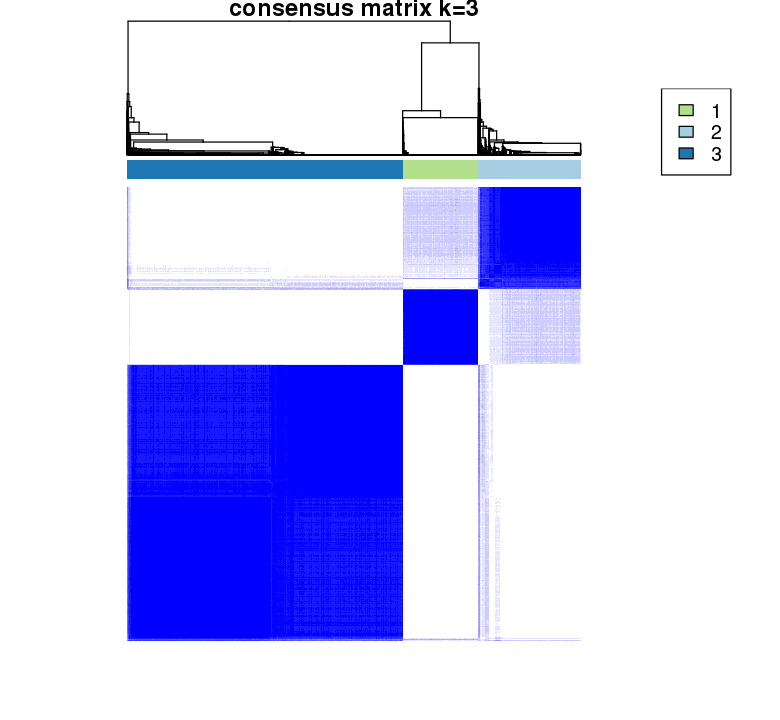

```
clustered
```

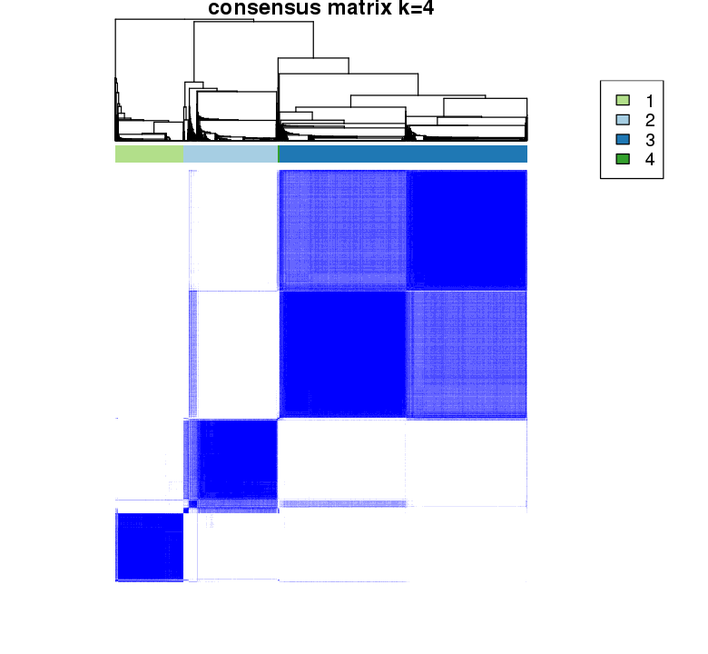

```
clustered
```

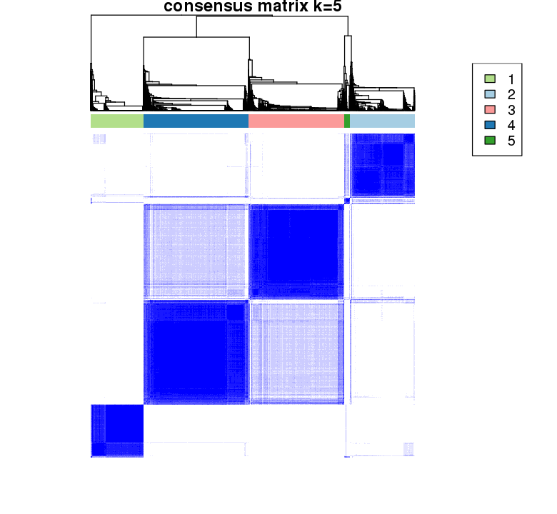

```
clustered
```

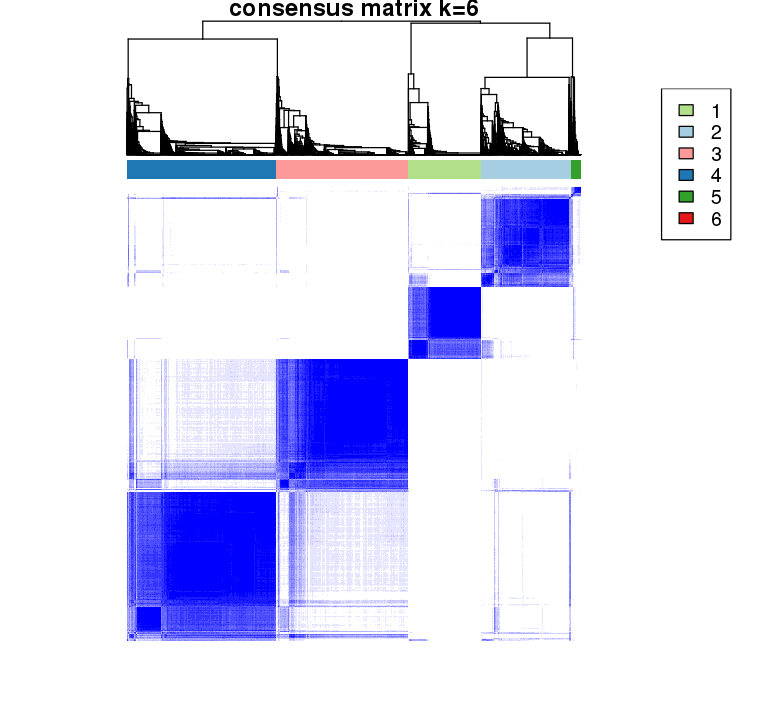

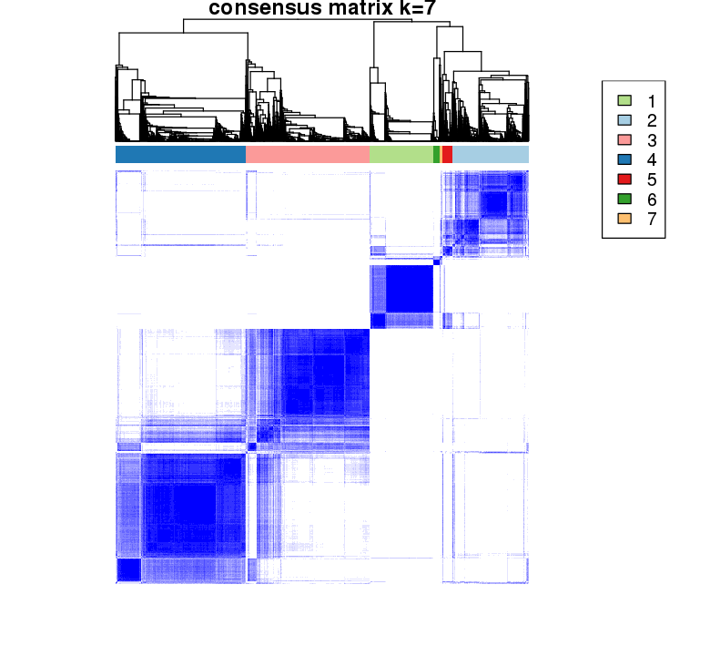

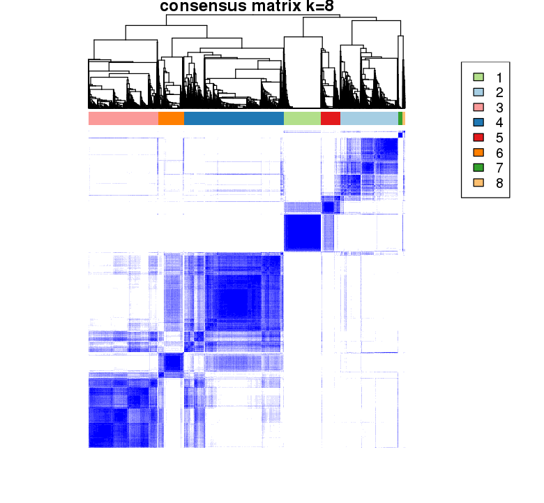

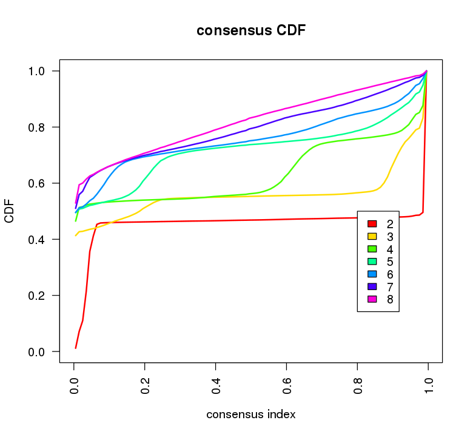

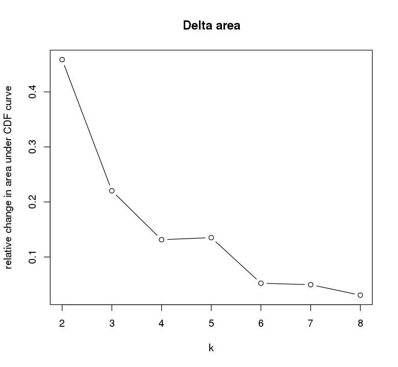

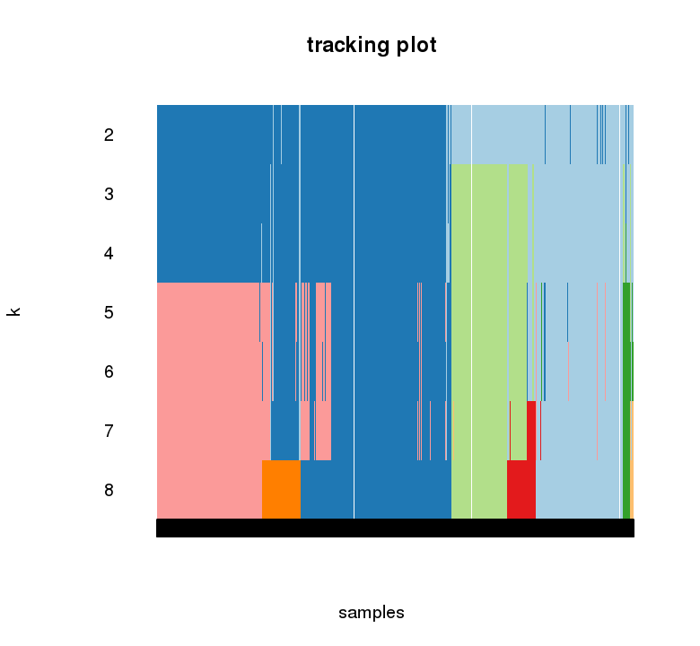

```r
res=ConsensusClusterPlus(
  as.matrix(t(data)), maxK = 8, reps=100, pItem=0.8, pFeature=1, clusterAlg="km", title="untitled_consensus_cluster",
  innerLinkage="average", finalLinkage="average", distance="euclidean", ml=NULL,
  tmyPal=NULL, seed=NULL, plot=NULL, writeTable=FALSE, weightsItem=NULL, weightsFeature=NULL,verbose=F)
```

As you can see, the ConsensusClusterPlus package allows for the evaluation of cluster membership stability and optimal cluster number with several graphical displays. This graphical output includes:

- **Consensus Matrices** (as heatmaps) for each number of k clusters. As more easy to define and delimite the clusters, more reliables they would be. Plot shows percent co-clustering for each sample in the consensus procedure (dark blue = 100%, white = 0%). Thus, a ‘perfect’ consensus clustering would have only blue squares in a block-diagonal fashion, while a dataset with no internal structure (no clusters) would display no block-diagonal squares. Upper colored horizontal bar shows final cluster assignment.
- **Consensus Cumulative Distribution Functions (CDF)**, to approximate at what k the cumulative distribution functions reach their maximum, and how it grows (if we are interested in reach a trade-off between number of clusters and a CDF value, for instance). The CDF shows the cumulative portion of all sample co-clustering at the given consensus index (1.0 = co-clustered 100% of the time) for each tested k. Generally, a more step-like curve is associated with more stable clustering.
- The **Delta area plot**, showing the relative change in total area under the CDF is shown below, where generally a greater area may suggest more stable clustering. We could be interested in the the greatest "elbow" of the line.
- The **tracking plot**, showing how cluster membership changes as k increases.
- The **Cluster-consensus plot** (in the next cell), showing the mean of all pairwise consensus values for a cluster’s members.

In the **heatmaps** above we can clearly identify different clusters for each configuration of k. Only with these representations, we could say that k = 2 offers the most defined and densed groups. However, split into 2 groups wouldn't be a good configuration to extract information. In this sense, k = 4 and k = 6, show clusters with lower "noise" around them comparing to the rest of configurations.

Regarding the **Delta Plot**, something weird happens in k = 5; however, from k = 6, the relative change in area under CDF curve is pretty lower.

Finally, we can bear out these conclusions with the **item-consensus** plots. From k = 5, the changes in item-consensus become more instable.

For all these reasons, we interpreted the tradeoff between CDF morphology and delta area as suggesting that **k = 6** to be most optimal. However, as we can read at the end of this notebooks (**Future Work**), a deeper analysis could provide more insights above the optimal number of clusters because this interpretation would be controversial.

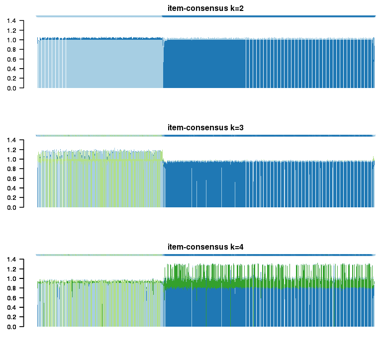

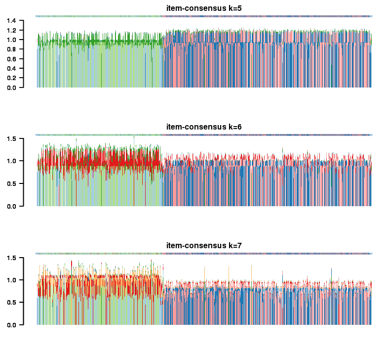

[output not shown]

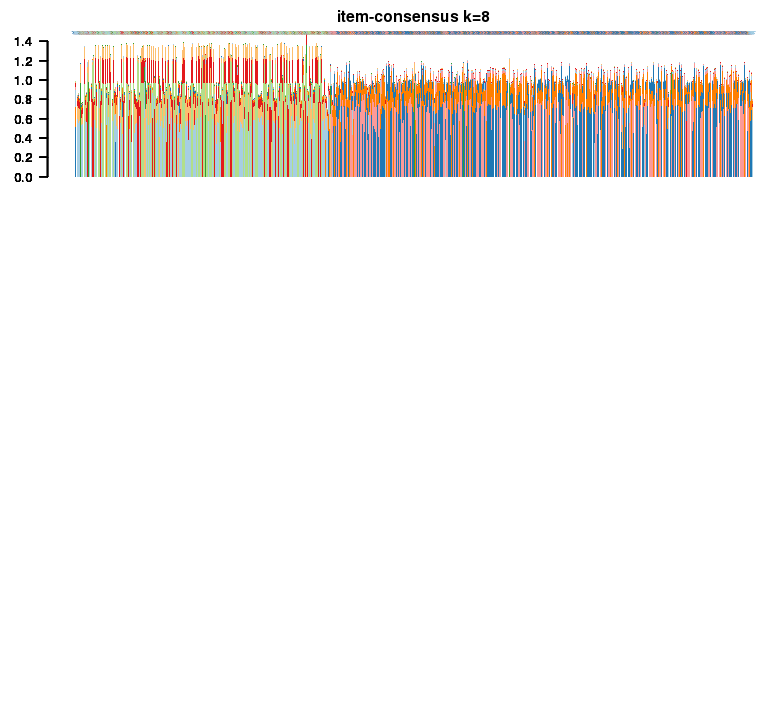

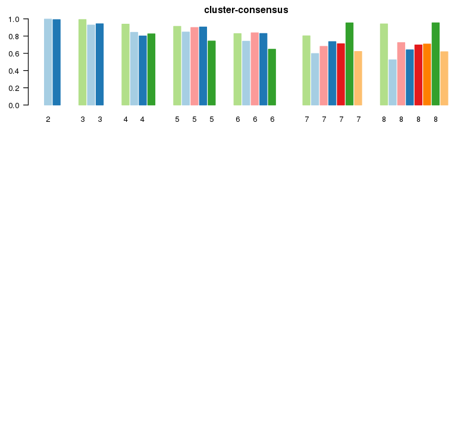

```r
calcICL(res,title="untitled_consensus_cluster",plot=NULL,writeTable=FALSE)
```

Let's save the cluster membership of each subject (row) to work with them:

```r
n_variables = dim(data)[2]
data$cluster2 = res[[2]]$consensusClass
data$cluster3 = res[[3]]$consensusClass
data$cluster4 = res[[4]]$consensusClass
data$cluster5 = res[[5]]$consensusClass
data$cluster6 = res[[6]]$consensusClass
data$cluster7 = res[[7]]$consensusClass
data$cluster8 = res[[8]]$consensusClass
head(data$cluster8, n = 20)
```

1. 1

2. 1

3. 2

4. 3

5. 1

6. 4

7. 5

8. 2

9. 3

10. 2

11. 6

12. 4

13. 3

14. 3

15. 4

16. 4

17. 4

18. 4

19. 1

20. 1

**Plotting the clusters** of each k-configuration:

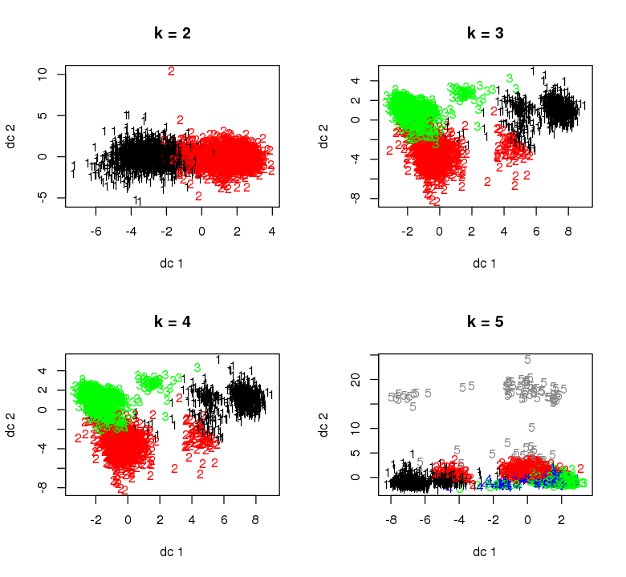

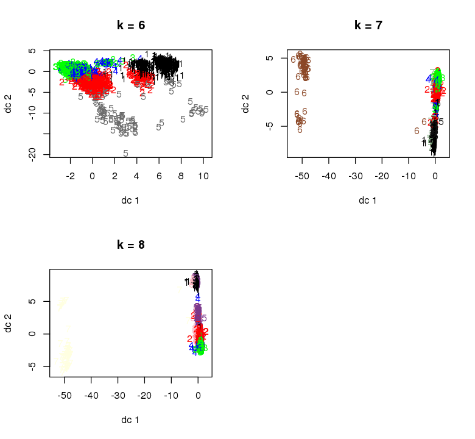

```r
library(fpc)
options(repr.plot.width=6.5, repr.plot.height=6)
par(mfrow = c(2,2))
plotcluster(as.matrix(data[,1:n_variables]), data$cluster2, main = "k = 2")#, xlab = "Eruption time (min)", ylab = "Waiting time to next eruption (min)")
plotcluster(as.matrix(data[,1:n_variables]), data$cluster3, main = "k = 3")
plotcluster(as.matrix(data[,1:n_variables]), data$cluster4, main = "k = 4")
plotcluster(as.matrix(data[,1:n_variables]), data$cluster5, main = "k = 5")
plotcluster(as.matrix(data[,1:n_variables]), data$cluster6, main = "k = 6")
plotcluster(as.matrix(data[,1:n_variables]), data$cluster7, main = "k = 7")
plotcluster(as.matrix(data[,1:n_variables]), data$cluster8, main = "k = 8")
```

As we said before, from k = 5, it's harder to identify and split each individual from his respective cluster. For instance, for k = 5, individuals from cluster 2, 3and 4 start to mixing in the plot, Although the cluster 5 is clearly different of the rest (maybe, they belong to the long tail of the distribution).

Moreover, we can get an idea of where are the **differences between clusters**. Those could be the variables that can identify each cluster.

For example, for **k=3**.

```r
names(data)
dim(data)
```

1. 'los_icu_cont'

2. 'aniongap_max'

3. 'bicarbonate_max'

4. 'creatinine_max'

5. 'chloride_min'

6. 'chloride_max'

7. 'glucose_min_x'

8. 'hematocrit_min'

9. 'hematocrit_max'

10. 'platelet_min'

11. 'potassium_min'

12. 'potassium_max'

13. 'ptt_max'

14. 'inr_max'

15. 'pt_min'

16. 'sodium_min'

17. 'sodium_max'

18. 'bun_min'

19. 'wbc_min'

20. 'wbc_max'

21. 'ph_max'

22. 'pco2_min'

23. 'o2_min'

24. 'o2_max'

25. 'ca_min'

26. 'ca_max'

27. 'mg_min'

28. 'mg_max'

29. 'heartrate_min'

30. 'heartrate_max'

31. 'heartrate_mean'

32. 'sysbp_min'

33. 'sysbp_mean'

34. 'diasbp_min'

35. 'diasbp_max'

36. 'diasbp_mean'

37. 'resprate_min'

38. 'resprate_max'

39. 'resprate_mean'

40. 'tempc_min'

41. 'tempc_max'

42. 'tempc_mean'

43. 'spo2_min'

44. 'spo2_max'

45. 'spo2_mean'

46. 'glucose_max_y'

47. 'glucose_mean'

48. 'height_min'

49. 'weight_min'

51. 'vent'

52. 'iot'

53. 'transfusion'

54. 'ecmo'

55. 'coro'

56. 'mechvent'

57. 'oxygentherapy'

58. 'extubated'

59. 'selfextubated'

60. 'sedation'

61. 'vasopressor'

62. 'gender'

63. 'rrt'

65. 'los_hospital'

66. 'age'

67. 'age_corrected'

68. 'cluster2'

69. 'cluster3'

70. 'cluster4'

71. 'cluster5'

72. 'cluster6'

73. 'cluster7'

74. 'cluster8'

1. 4360

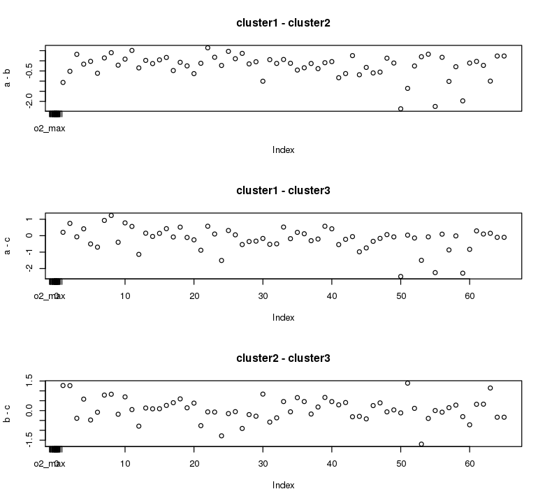

```r
pos = which((data$cluster3 == 1) == TRUE)
a = colMeans(data[pos,1:n_variables])
pos = which((data$cluster3 == 2) == TRUE)
b = colMeans(data[pos,1:n_variables])
pos = which((data$cluster3 == 3) == TRUE)
c = colMeans(data[pos,1:n_variables])

par(mfrow = c(3,1))
plot(a-b, main = "cluster1 - cluster2", xaxt = 'n')
axis(1, at = a, labels = names(data[pos,1:n_variables]))
plot(a-c, main = "cluster1 - cluster3")
axis(1, at = a, labels = names(data[pos,1:n_variables]))
plot(b-c, main = "cluster2 - cluster3")
axis(1, at = a, labels = names(data[pos,1:n_variables]))
```

And the **differences** between the clusters with **k = 4.**

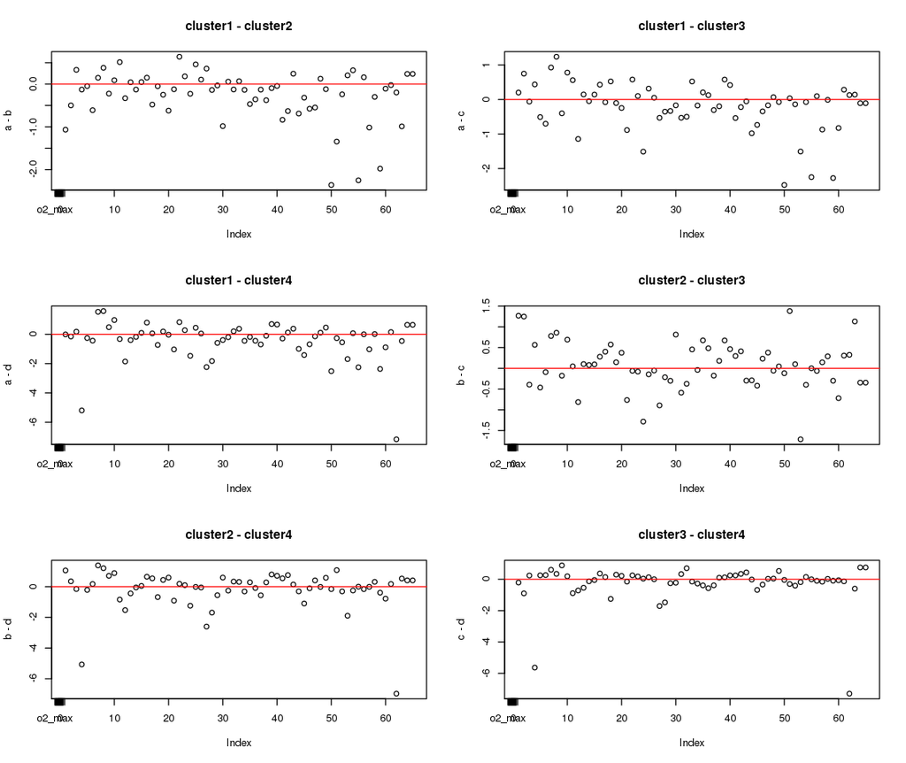

```r
pos = which((data$cluster4 == 1) == TRUE)
a = colMeans(data[pos,1:n_variables])
pos = which((data$cluster4 == 2) == TRUE)
b = colMeans(data[pos,1:n_variables])
pos = which((data$cluster4 == 3) == TRUE)
c = colMeans(data[pos,1:n_variables])
pos = which((data$cluster4 == 4) == TRUE)
d = colMeans(data[pos,1:n_variables])

par(mfrow = c(3,2))
plot(a-b, main = "cluster1 - cluster2")
axis(1, at = a, labels = names(data[pos,1:n_variables]))
abline(h=0, col="red")
plot(a-c, main = "cluster1 - cluster3")
axis(1, at = a, labels = names(data[pos,1:n_variables]))
abline(h=0, col="red")
plot(a-d, main = "cluster1 - cluster4")
axis(1, at = a, labels = names(data[pos,1:n_variables]))
abline(h=0, col="red")
plot(b-c, main = "cluster2 - cluster3")
axis(1, at = a, labels = names(data[pos,1:n_variables]))
abline(h=0, col="red")
plot(b-d, main = "cluster2 - cluster4")
axis(1, at = a, labels = names(data[pos,1:n_variables]))
abline(h=0, col="red")
plot(c-d, main = "cluster3 - cluster4")
axis(1, at = a, labels = names(data[pos,1:n_variables]))
abline(h=0, col="red")
```

And for **k = 6**:

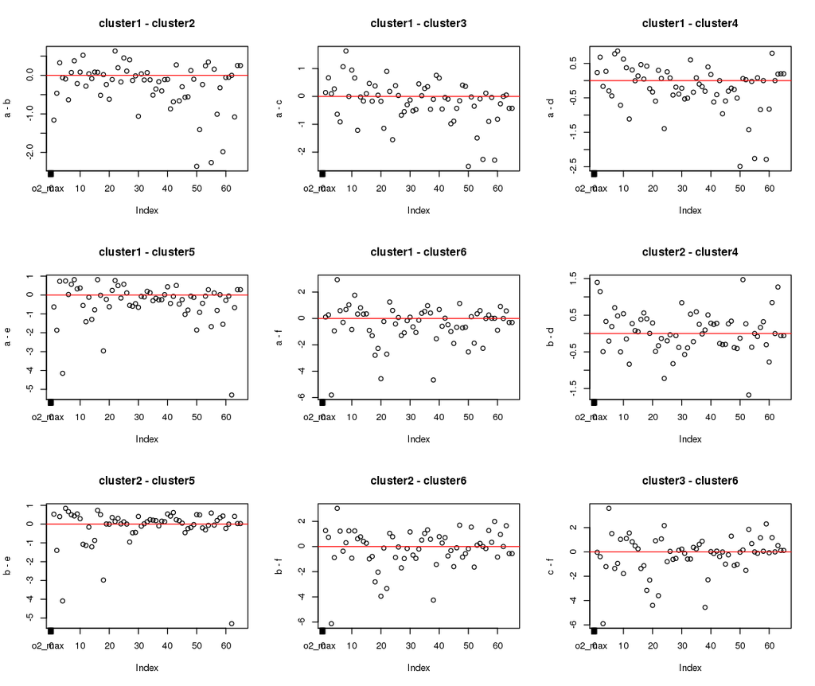

```r
pos = which((data$cluster6 == 1) == TRUE)
a = colMeans(data[pos,1:n_variables])
pos = which((data$cluster6 == 2) == TRUE)
b = colMeans(data[pos,1:n_variables])
pos = which((data$cluster6 == 3) == TRUE)
c = colMeans(data[pos,1:n_variables])
pos = which((data$cluster6 == 4) == TRUE)
d = colMeans(data[pos,1:n_variables])
pos = which((data$cluster6 == 5) == TRUE)
e = colMeans(data[pos,1:n_variables])
pos = which((data$cluster6 == 6) == TRUE)
f = colMeans(data[pos,1:n_variables])

par(mfrow = c(3,3))
plot(a-b, main = "cluster1 - cluster2")
axis(1, at = a, labels = names(data[pos,1:n_variables]))
abline(h=0, col="red")
plot(a-c, main = "cluster1 - cluster3")
axis(1, at = a, labels = names(data[pos,1:n_variables]))
abline(h=0, col="red")
plot(a-d, main = "cluster1 - cluster4")
axis(1, at = a, labels = names(data[pos,1:n_variables]))
abline(h=0, col="red")
plot(a-e, main = "cluster1 - cluster5")
axis(1, at = a, labels = names(data[pos,1:n_variables]))
abline(h=0, col="red")
plot(a-f, main = "cluster1 - cluster6")
axis(1, at = a, labels = names(data[pos,1:n_variables]))
abline(h=0, col="red")
plot(b-d, main = "cluster2 - cluster4")
axis(1, at = a, labels = names(data[pos,1:n_variables]))
abline(h=0, col="red")
plot(b-e, main = "cluster2 - cluster5")
axis(1, at = a, labels = names(data[pos,1:n_variables]))
abline(h=0, col="red")
plot(b-f, main = "cluster2 - cluster6")
axis(1, at = a, labels = names(data[pos,1:n_variables]))
abline(h=0, col="red")
plot(c-f, main = "cluster3 - cluster6")
axis(1, at = a, labels = names(data[pos,1:n_variables]))
abline(h=0, col="red")
```

To acquire a better idea of the relevance of these differences between variables (theoretically, these variables allow the creation of the different clusters), let's first do a supervised Feature subset Selection with Boruta algorithm in the next stage. This could offer us an idea about wheter these variables are the same than considered as important to predict the LOS_ICU or not.

In the affirmative case, our hypothesis about to split the problem in different sub-groups of care-patient's necessities could be factible.

**BORUTA: FEATURES SELECTION**

Boruta [4,5] is a feature selection algorithm. Precisely, it works as a wrapper algorithm around Random Forest. It is particularly useful when one is interested in understanding the mechanisms related to the variable of interest, rather than just building a black box predictive model with good prediction accuracy.

Boruta is an easy to use package as there aren’t many parameters to tune / remember. You shouldn’t use a data set with missing values to check important variables using Boruta. It’ll blatantly throw errors. You can use this algorithm on any classification / regression problem in hand to come up with a subset of meaningful features.

**How it works?**

1. Create duplicate copies of all independent variables. When the number of independent variables in the original data is less than 5, create at least 5 copies using existing variables.
2. Shuffle the values of added duplicate copies to remove their correlations with the target variable. It is called shadow features or permuted copies.
3. Combine the original ones with shuffled copies
4. Run a random forest classifier on the combined dataset and performs a variable importance measure (the default is Mean Decrease Accuracy) to evaluate the importance of each variable where higher means more important.
5. Then Z score is computed. It means mean of accuracy loss divided by standard deviation of accuracy loss.
6. Find the maximum Z score among shadow attributes (MZSA)
7. Tag the variables as 'unimportant' when they have importance significantly lower than MZSA. Then we permanently remove them from the process.
8. Tag the variables as 'important' when they have importance significantly higher than MZSA.
9. Repeat the above steps for predefined number of iterations (random forest runs), or until all attributes are either tagged 'unimportant' or 'important', whichever comes first.

**What makes it different from traditional feature selection algorithms?**

Boruta follows an all-relevant feature selection method where it captures all features which are in some circumstances relevant to the outcome variable. In contrast, most of the traditional feature selection algorithms follow a minimal optimal method where they rely on a small subset of features which yields a minimal error on a chosen classifier.

While fitting a random forest model on a data set, you can recursively get rid of features in each iteration which didn’t perform well in the process. This will eventually lead to a minimal optimal subset of features as the method minimizes the error of random forest model. This happens by selecting an over-pruned version of the input data set, which in turn, throws away some relevant features.

On the other hand, boruta find all features which are either strongly or weakly relevant to the decision variable. This makes it well suited for biomedical applications where one might be interested to determine which human genes (features) are connected in some way to a particular medical condition (target variable).

**Summarising:**

Perform shuffling of predictors' values and join them with the original predictors and then build random forest on the merged dataset. Then make comparison of original variables with the randomised variables to measure variable importance. Only variables having higher importance than that of the randomised variables are considered important.

- It works well for both classification and regression problem.
- It takes into account multi-variable relationships.
- It is an improvement on random forest variable importance measure which is a very popular method for variable selection.
- It follows an all-relevant variable selection method in which it considers all features which are relevant to the outcome variable. Whereas, most of the other variable selection algorithms follow a minimal optimal method where they rely on a small subset of features which yields a minimal error on a chosen classifier.
- It can handle interactions between variables
- It can deal with fluctuating nature of random a random forest importance measure
- **Important points related to Boruta** [6]:

  ```
   - Impute missing values - Make sure missing or blank values are filled up before running boruta algorithm.
   - Collinearity - It is important to handle collinearity after getting important variables from boruta.
   - Slow Speed - It is slow in terms of speed as compared to other traditional feature selection algorithms.
  ```

```r
install.packages("Boruta")
library(Boruta)
```

We'll make more though the test: we will **also include the categorical variables** to get the variable importance of the dataset.

```r
boruta_data = Boruta(data$los_icu_cont ~ ., data = data_or, doTrace = 0, mcAdj = TRUE, getImp = getImpRfZ)
```

Boruta provides a result with 3 classes of variables: **confirmed** as importants, **tentative** (when it have enough importance but not the statistic significance of p < 0.05) and **rejected** variables.

Let's visualize these results in a plot with the relative importances:

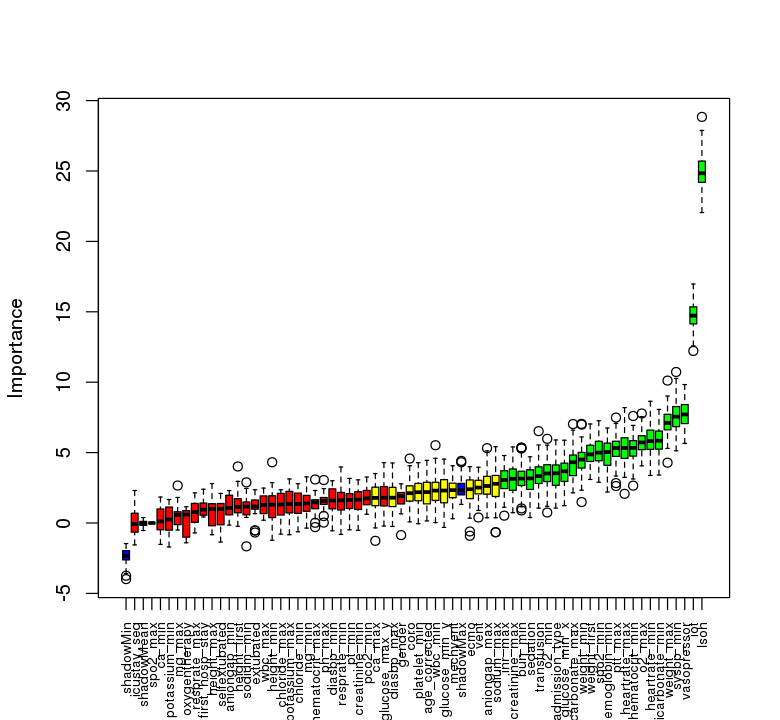

```r
plot(boruta_data, xlab = "", xaxt = "n")
lz = lapply(1:ncol(boruta_data$ImpHistory),
            function(i) boruta_data$ImpHistory[is.finite(boruta_data$ImpHistory[,i]),i])

names(lz) = colnames(boruta_data$ImpHistory)
Labels = sort(sapply(lz,median))
axis(side = 1,las=2,labels = names(Labels), at = 1:ncol(boruta_data$ImpHistory), cex.axis = 0.7)
```

So, the **variables selected as relevants to the ICU Length Of Stay** (including the tentative ones) are:

```r
final.boruta = TentativeRoughFix(boruta_data)
print("Total selected variables:")
length(getSelectedAttributes(final.boruta, withTentative = T))
print("The selected variables are:")
getSelectedAttributes(final.boruta, withTentative = T)
```

```
[1] "Total selected variables:"
```

30

```
[1] "The selected variables are:"
```

1. 'aniongap_max'

2. 'bicarbonate_min'

3. 'bicarbonate_max'

4. 'creatinine_max'

5. 'glucose_min_x'

6. 'hematocrit_min'

7. 'hemoglobin_min'

8. 'ptt_max'

9. 'inr_max'

10. 'bun_min'

11. 'wbc_min'

12. 'o2_min'

13. 'o2_max'

14. 'heartrate_min'

15. 'heartrate_max'

16. 'sysbp_min'

17. 'diasbp_max'

18. 'spo2_min'

19. 'glucose_min_y'

20. 'weight_first'

21. 'weight_min'

22. 'weight_max'

23. 'admission_type'

24. 'vent'

25. 'iot'

26. 'transfusion'

27. 'mechvent'

28. 'sedation'

29. 'vasopressor'

30. 'lsoh'

You can get more info about the statistics of the process:

```r
attStats(final.boruta)
```

|  | meanImp | medianImp | minImp | maxImp | normHits | decision |
| --- | --- | --- | --- | --- | --- | --- |
| aniongap_min | 1.1465717 | 1.0699313 | -0.14965751 | 2.304656 | 0.00000000 | Rejected |
| aniongap_max | 2.6246097 | 2.6298798 | 0.37104918 | 5.315781 | 0.56565657 | Confirmed |
| bicarbonate_min | 5.8873573 | 5.8421393 | 3.40868154 | 8.067408 | 1.00000000 | Confirmed |
| bicarbonate_max | 4.1998060 | 4.3132622 | 2.14432781 | 7.027955 | 0.89898990 | Confirmed |
| creatinine_min | 1.6086483 | 1.6590561 | -0.52170537 | 3.065978 | 0.09090909 | Rejected |
| creatinine_max | 3.0652893 | 3.1373160 | 0.73194874 | 5.400946 | 0.68686869 | Confirmed |
| chloride_min | 1.2731850 | 1.3537435 | -0.62194211 | 2.789651 | 0.00000000 | Rejected |
| chloride_max | 1.1453143 | 1.3112554 | -0.79052360 | 2.359246 | 0.01010101 | Rejected |
| glucose_min_x | 3.5945788 | 3.6709733 | 1.23501090 | 5.878166 | 0.79797980 | Confirmed |
| hematocrit_min | 5.2462044 | 5.3374154 | 2.65285578 | 7.598373 | 1.00000000 | Confirmed |
| hematocrit_max | 1.2841623 | 1.4699851 | -0.29129364 | 3.090905 | 0.00000000 | Rejected |
| hemoglobin_min | 4.8476048 | 5.0386700 | 2.20031867 | 6.743977 | 0.96969697 | Confirmed |
| platelet_min | 2.1867403 | 2.1869772 | -0.05074599 | 4.282661 | 0.39393939 | Rejected |
| potassium_min | 0.3452830 | 0.2491487 | -1.70234858 | 1.668194 | 0.00000000 | Rejected |
| potassium_max | 1.3685283 | 1.3505834 | -0.83163971 | 3.128668 | 0.03030303 | Rejected |
| ptt_max | 5.2869275 | 5.3228851 | 2.62428650 | 7.487891 | 1.00000000 | Confirmed |
| inr_max | 2.9957132 | 3.0560189 | 0.52229685 | 4.791529 | 0.69696970 | Confirmed |
| pt_min | 1.5824883 | 1.6334391 | -0.48187825 | 3.165692 | 0.03030303 | Rejected |
| sodium_min | 1.1269820 | 1.1651996 | -1.65763129 | 2.887003 | 0.00000000 | Rejected |
| sodium_max | 2.6877569 | 2.7846410 | -0.65746054 | 5.417594 | 0.60606061 | Rejected |
| bun_min | 3.1287373 | 3.1532146 | 0.89196409 | 5.357893 | 0.72727273 | Confirmed |
| wbc_min | 2.2667913 | 2.3008801 | 0.02814716 | 5.524214 | 0.39393939 | Confirmed |
| wbc_max | 1.3359853 | 1.2839546 | 0.19510648 | 2.479183 | 0.01010101 | Rejected |
| ph_max | 1.5390821 | 1.5646418 | 0.03012085 | 3.051446 | 0.01010101 | Rejected |
| pco2_min | 1.8723381 | 1.7462616 | 0.62342476 | 3.263399 | 0.02020202 | Rejected |
| o2_min | 3.5540143 | 3.5177452 | 0.74662619 | 5.978890 | 0.87878788 | Confirmed |
| o2_max | 5.7604523 | 5.7194151 | 4.05873927 | 7.779002 | 1.00000000 | Confirmed |
| ca_min | 0.1455144 | 0.1141897 | -1.52118467 | 1.844418 | 0.00000000 | Rejected |
| ca_max | 1.8035215 | 1.7826943 | -1.26454328 | 3.511166 | 0.35353535 | Rejected |
| mg_min | 1.3884708 | 1.3919656 | -0.36128348 | 3.275691 | 0.04040404 | Rejected |
| ⋮ | ⋮ | ⋮ | ⋮ | ⋮ | ⋮ | ⋮ |
| diasbp_max | 1.78745413 | 1.79724247 | -0.24469019 | 4.262184 | 0.37373737 | Confirmed |
| resprate_min | 1.55074624 | 1.61117606 | -0.81170921 | 3.974739 | 0.08080808 | Rejected |
| resprate_max | 0.75835824 | 0.76969974 | -0.70242656 | 2.137405 | 0.01010101 | Rejected |
| spo2_min | 5.08126548 | 4.99991826 | 2.89537072 | 7.259440 | 1.00000000 | Confirmed |
| spo2_max | 0.00000000 | 0.00000000 | 0.00000000 | 0.000000 | 0.00000000 | Rejected |
| glucose_min_y | 2.24983024 | 2.30714912 | -0.30947895 | 4.532219 | 0.45454545 | Confirmed |
| glucose_max_y | 1.88598094 | 1.79640981 | -0.21671631 | 4.286575 | 0.23232323 | Rejected |
| height_first | 1.30040493 | 1.14228609 | -0.23527048 | 4.014648 | 0.03030303 | Rejected |
| height_min | 1.22969065 | 1.30285455 | -1.22496700 | 4.315009 | 0.09090909 | Rejected |
| height_max | 0.76913276 | 0.98748891 | -0.83157249 | 2.799528 | 0.00000000 | Rejected |
| weight_first | 4.94460692 | 4.87453404 | 3.09389952 | 7.033869 | 0.97979798 | Confirmed |
| weight_min | 4.46890371 | 4.50561225 | 1.48729312 | 7.040085 | 0.94949495 | Confirmed |
| weight_max | 7.12958996 | 7.10506607 | 4.28651475 | 10.115451 | 1.00000000 | Confirmed |
| admission_type | 3.44676134 | 3.53120707 | 1.06080591 | 5.896204 | 0.81818182 | Confirmed |
| vent | 2.51411637 | 2.51350959 | 0.39130435 | 3.960084 | 0.57575758 | Confirmed |
| iot | 14.69547863 | 14.72992729 | 12.22144263 | 16.973309 | 1.00000000 | Confirmed |
| transfusion | 3.39026588 | 3.32745684 | 1.05808237 | 6.522479 | 0.79797980 | Confirmed |
| ecmo | 2.30614412 | 2.39766098 | -0.90857044 | 3.999112 | 0.48484848 | Rejected |
| coro | 2.09873498 | 2.11665926 | 0.08358875 | 4.577006 | 0.33333333 | Rejected |
| mechvent | 2.29752449 | 2.33333829 | 0.30589953 | 4.064204 | 0.44444444 | Confirmed |
| oxygentherapy | 0.11925250 | 0.60021777 | -1.40280749 | 1.155944 | 0.00000000 | Rejected |
| extubated | 1.07279542 | 1.17313851 | -0.67512960 | 2.361567 | 0.01010101 | Rejected |
| selfextubated | 0.64447339 | 1.00100150 | -1.35272382 | 2.098460 | 0.00000000 | Rejected |
| first_hosp_stay | 1.08227133 | 0.94911587 | 0.42797751 | 2.397175 | 0.00000000 | Rejected |
| sedation | 3.03297733 | 3.16972548 | 0.38886434 | 4.702334 | 0.69696970 | Confirmed |
| vasopressor | 7.74995701 | 7.70703870 | 5.65039297 | 9.831486 | 1.00000000 | Confirmed |
| gender | 1.66554668 | 1.91635101 | -0.86074501 | 2.780975 | 0.01010101 | Rejected |
| icustay_seq | 0.04719633 | -0.08383734 | -1.55422340 | 2.306679 | 0.00000000 | Rejected |
| lsoh | 24.88931018 | 24.83714222 | 22.04879875 | 28.842777 | 1.00000000 | Confirmed |
| age_corrected | 2.14280640 | 2.19671823 | 0.14861055 | 4.450785 | 0.43434343 | Rejected |

**FINAL CONCLUSIONS**

For example, for the (probably) most stable configuration (k = 6):

```r
print("From the clusters 1 and 2")
sort(abs((a-b)), decreasing = TRUE)[1:10]  # Main variables that makes differences between clusters 1 and 2
print("From the clusters 1 and 3")
sort(abs((a-c)), decreasing = TRUE)[1:10]  # Main variables that makes differences between clusters 1 and 3
print("From the clusters 1 and 4")
sort(abs((a-d)), decreasing = TRUE)[1:10]  # Main variables that makes differences between clusters 1 and 4
print("From the clusters 1 and 5")
sort(abs((a-e)), decreasing = TRUE)[1:10]  # Main variables that makes differences between clusters 1 and 4
print("From the clusters 1 and 6")
sort(abs((a-f)), decreasing = TRUE)[1:10]  # Main variables that makes differences between clusters 1 and 4
print("From the clusters 2 and 3")
sort(abs((b-c)), decreasing = TRUE)[1:10]  # Main variables that makes differences between clusters 2 and 3
print("From the clusters 2 and 4")
sort(abs((b-d)), decreasing = TRUE)[1:10]  # Main variables that makes differences between clusters 2 and 4
print("From the clusters 2 and 5")
sort(abs((b-e)), decreasing = TRUE)[1:10]  # Main variables that makes differences between clusters 2 and 4
print("From the clusters 2 and 6")
sort(abs((b-f)), decreasing = TRUE)[1:10]  # Main variables that makes differences between clusters 2 and 4
print("From the clusters 3 and 4")
sort(abs((c-d)), decreasing = TRUE)[1:10]  # Main variables that makes differences between clusters 3 and 4
```

```
[1] "From the clusters 1 and 2"
```

**vent**

2.3606622954663

**mechvent**

2.26342566482233

**sedation**

1.98166910571078

**iot**

1.40865073570814

**los_icu_cont**

1.16052865915801

**los_hospital**

1.07895032258038

**heartrate_max**

1.06158887757628

**extubated**

1.00866987944135

**tempc_max**

0.870150579632271

**tempc_mean**

0.686663571675466

```
[1] "From the clusters 1 and 3"
```

**vent**

2.5082547089037

**sedation**

2.28635301558681

**mechvent**

2.26103938699197

**hematocrit_min**

1.63006891078614

**o2_max**

1.5536189236778

**ecmo**

1.491123791556

**potassium_max**

1.2163211090426

**ph_max**

1.14374350009626

**glucose_min_x**

1.06714368816683

**spo2_max**

0.980514145143733

```
[1] "From the clusters 1 and 4"
```

**vent**

2.48811563381029

**sedation**

2.2870476024115

**mechvent**

2.26130601021324

**ecmo**

1.42688174813002

**o2_max**

1.39458467251978

**potassium_max**

1.11433983893485

**spo2_max**

0.962067128101191

**hematocrit_min**

0.859631908986237

**extubated**

0.843257058796464

**vasopressor**

0.828482850586807

```
[1] "From the clusters 1 and 5"
```

**rrt**

5.29897411947194

**creatinine_max**

4.15071779825847

**bun_min**

2.9609880804075

**aniongap_max**

1.86480401119457

**vent**

1.85572365239294

**mechvent**

1.67494033212581

**sedation**

1.55109291325328

**potassium_max**

1.41498211406526

**inr_max**

1.29332769070904

**glucose_max_y**

1.02732916706028

```
[1] "From the clusters 1 and 6"
```

**bicarbonate_max**

5.80336263467698

**resprate_max**

4.66327660002025

**wbc_max**

4.56963464497476

**chloride_min**

2.94205796897084

**bun_min**

2.79130490385675

**pco2_min**

2.70340458001153

**vent**

2.53649674705931

**wbc_min**

2.27226339350834

**mechvent**

2.26342566482233

**spo2_mean**

1.8928815727248

```
[1] "From the clusters 2 and 3"
```

**ecmo**

1.73938002754839

**iot**

1.38917808147033

**o2_max**

1.38284897148337

**los_icu_cont**

1.3004398963863

**hematocrit_min**

1.2519309952633

**aniongap_max**

1.13294346401587

**los_hospital**

1.13041961093202

**mg_min**

1.07729711160619

**ph_max**

1.03574255154986

**glucose_min_x**

0.993258496390458

```
[1] "From the clusters 2 and 4"
```

**ecmo**

1.6751379841224

**iot**

1.46906663177381

**los_icu_cont**

1.39479724450437

**los_hospital**

1.26911622075586

**o2_max**

1.22381472032536

**aniongap_max**

1.14502058437199

**gender**

0.844348045946865

**heartrate_max**

0.840830063139486

**potassium_max**

0.834497381265884

**mg_min**

0.821981603678324

```
[1] "From the clusters 2 and 5"
```

**rrt**

5.29897411947194

**creatinine_max**

4.09031817997472

**bun_min**

2.97937816920691

**aniongap_max**

1.40090919890202

**inr_max**

1.20896023780417

**potassium_max**

1.1351396563963

**potassium_min**

1.0757028619428

**mg_min**

0.952613258990993

**pt_min**

0.870532761995367

**chloride_min**

0.838628478396879

```
[1] "From the clusters 2 and 6"
```

**bicarbonate_max**

6.12981206446117

**resprate_max**

4.25875958440375

**wbc_max**

3.95013146053754

**pco2_min**

3.33533266752213

**chloride_min**

3.03530636503062

**bun_min**

2.80969499265615

**wbc_min**

2.03473846880843

**sedation**

1.99544036005929

**mg_min**

1.6951126060253

**glucose_mean**

1.69495196569845

```
[1] "From the clusters 3 and 4"
```

**gender**

1.05992263910063

**weight_min**

0.869254649898844

**hematocrit_min**

0.770437001799901

**hematocrit_max**

0.714300156839562

**height_min**

0.662371854995068

**age**

0.623938572200268

**age_corrected**

0.623938572200268

**pco2_min**

0.598375982962069

**ph_max**

0.548493940938972

**tempc_min**

0.481757803192845

The optimal number of clusters found in this work is k = 6, as in [1]. However, we can't see the differences between subgroups of patients as clear than them.

The main difference between both works are the variables and the cohort (altough they are similar population in theory) for the analysis. In this case, we didn't use important variables as *severity of illnes*, *vital state at discharge time*, *total days of sedation* (only if they were sedated or not), etc. so likely would say our approach would be more naive, but more generalizable and interesting in the point of view of prediction (most of our variables comes from the first 24h). eEither way, more work in the model is required.

**FUTURE WORK**

The following plot shows the distribution of each cluster (for k = 4 and k = 6) along the LOS_ICU histogram. Some pattern could be identified, although more work is needed. New approaches would include new variables that improve the results or the boundaries between clusters.

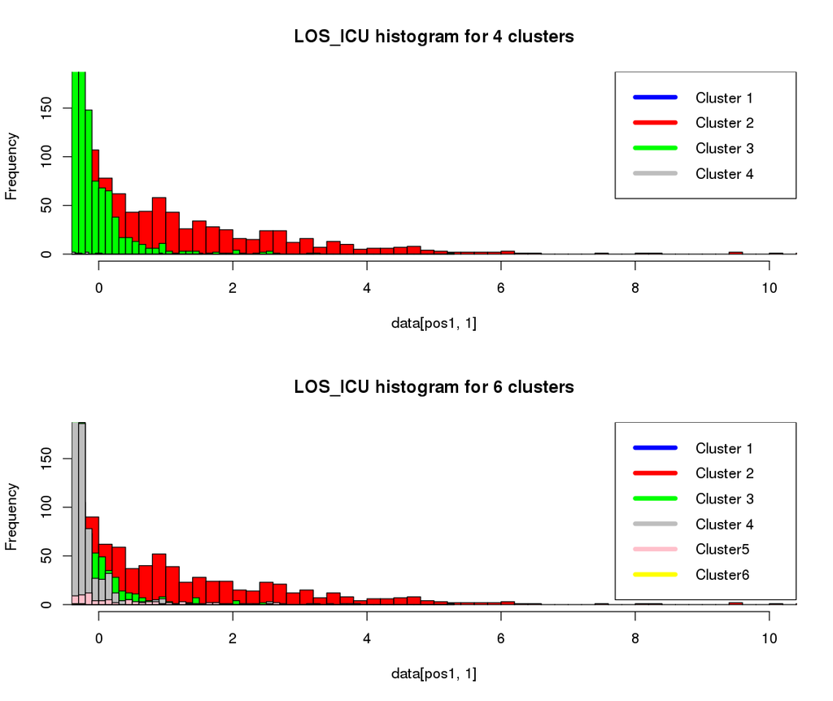

```r
par(mfrow=c(2,1))
options(repr.plot.width=9.5, repr.plot.height=8)
pos1 = which((data$cluster4 == 1) == TRUE)
a = colMeans(data[pos,1:n_variables])
pos2 = which((data$cluster4 == 2) == TRUE)
b = colMeans(data[pos,1:n_variables])
pos3 = which((data$cluster4 == 3) == TRUE)
c = colMeans(data[pos,1:n_variables])
pos4 = which((data$cluster4 == 4) == TRUE)
d = colMeans(data[pos,1:n_variables])


hist(data[pos1,1], col="blue", xlim=c(0,10), ylim=c(0,180), breaks = 50, main = "LOS_ICU histogram for 4 clusters")  # first histogram
hist(data[pos2,1], col="red", xlim=c(0,10), ylim=c(0,180), breaks = 50, add=T)  # second
hist(data[pos3,1], col="green", xlim=c(0,10), ylim=c(0,180), breaks = 50, add=T)  # second
hist(data[pos4,1], col="grey", xlim=c(0,10), ylim=c(0,180), breaks = 50, add=T)  # second
legend("topright", c("Cluster 1", "Cluster 2", "Cluster 3", "Cluster 4"), col=c("blue", "red", "green", "grey"), lwd=5)

# k = 6
pos1 = which((data$cluster6 == 1) == TRUE)
a = colMeans(data[pos,1:n_variables])
pos2 = which((data$cluster6 == 2) == TRUE)
b = colMeans(data[pos,1:n_variables])
pos3 = which((data$cluster6 == 3) == TRUE)
c = colMeans(data[pos,1:n_variables])
pos4 = which((data$cluster6 == 4) == TRUE)
d = colMeans(data[pos,1:n_variables])
pos5 = which((data$cluster6 == 5) == TRUE)
e = colMeans(data[pos,1:n_variables])
pos6 = which((data$cluster6 == 6) == TRUE)
f = colMeans(data[pos,1:n_variables])

hist(data[pos1,1], col="blue", xlim=c(0,10), ylim=c(0,180), breaks = 50, main = "LOS_ICU histogram for 6 clusters")  # first histogram
hist(data[pos2,1], col="red", xlim=c(0,10), ylim=c(0,180), breaks = 50, add=T)  # second
hist(data[pos3,1], col="green", xlim=c(0,10), ylim=c(0,180), breaks = 50, add=T)  # second
hist(data[pos4,1], col="grey", xlim=c(0,10), ylim=c(0,180), breaks = 50, add=T)  # second
hist(data[pos5,1], col="pink", xlim=c(0,10), ylim=c(0,180), breaks = 50, add=T)  # second
hist(data[pos6,1], col="yellow", xlim=c(0,10), ylim=c(0,180), breaks = 50, add=T)  # second
legend("topright", c("Cluster 1", "Cluster 2", "Cluster 3", "Cluster 4", "Cluster5", "Cluster6"), col=c("blue", "red", "green", "grey", "pink", "yellow"), lwd=5)
```

*REFERENCES* :

*[1] Identifying Distinct Subgroups of ICU Patients: A Machine Learning Approach. Vranas KC. et al. Crit. Care Med. (Oct. 2017). https://www.ncbi.nlm.nih.gov/pubmed/28640021*

*[2] ConsensusClusterPlus: a class discovery tool with confidence assessments and item tracking. Matthew D. Wilkerson. Bioinformatics (2010). https://www.ncbi.nlm.nih.gov/pmc/articles/PMC2881355/*

*[3] ConsensusClusterPlus (Tutorial). Matthew D. Wilkerson (2017). https://www.bioconductor.org/packages/devel/bioc/vignettes/ConsensusClusterPlus/inst/doc/ConsensusClusterPlus.pdf*

*[4] https://cran.r-project.org/web/packages/Boruta/Boruta.pdf*

*[5] Feature Selection with the Boruta Package. Miron B. Kursa et al. Jurnal of Statistics Software (2010).*

*[6] https://www.listendata.com/2017/05/feature-selection-boruta-package.html*

*[7] https://www.biostars.org/p/198789/*